# A barrier model illustration

### The fitted field

We can visualize summaries from the fitted field. The posterior mean and the standard error can be projected into small pixels and added to the raster data with

```r
grid.df$u.mean <- as.vector(
  inla.mesh.project(
    pgrid,
    result$summary.random$field$mean))
grid.df$u.sd <- as.vector(
  inla.mesh.project(
    pgrid,
    result$summary.random$field$sd))
```

To help the visualization, we will filter the grid pixels considering the barriers.

```r
gInBarrier <-
  (splancs::inout(cbind(grid.df$x, grid.df$y), barrier1)) |
  (splancs::inout(cbind(grid.df$x, grid.df$y), barrier2))
```

We can now visualize the posterior mean with

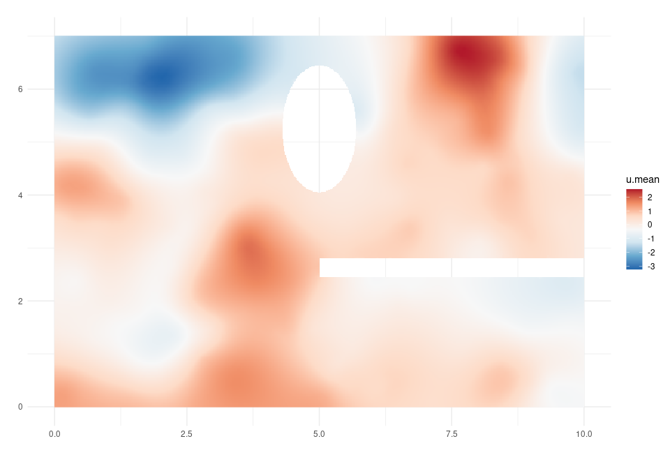

```r
ggplot() +
  geom_raster(
    data = grid.df[!gInBarrier, ],
    aes(x = x, y = y, fill = u.mean)) +
  gg.add ## look to the appendix for the code for this
```

The estimated field, considering the posterior mean shown, exhibits a different pattern in each side of the barrier, particularly far from its tip. Therefore we successfully accounted for the barrier in the model. See [this tutorial](https://haakonbakkagit.github.io/btopic128.html) for details and how to visualize the implied correlation between two points.

Similarly, we can plot the posterior standard deviation of the field, and the data locations used to estimate the model. This has lower values around more densely sampled locations and higher values otherwise. The highest are near the boundaries, including the boundary at the barriers, and far from observed locations.

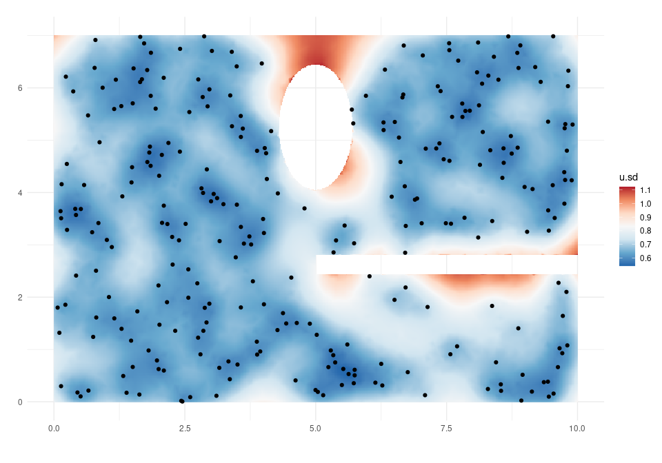

```r
ggplot() +
  geom_raster(
    data = grid.df[!gInBarrier, ],
    aes(x = x, y = y, fill = u.sd)) +
  geom_point(data = dataset, aes(x = x, y = y)) +
  gg.add ## look to the appendix for the code for this
```

# Appendix A: re-used code

The additional **ggplot2** code used

```r
gg.add <- list(
  scale_fill_distiller(
    type = "div",
    palette = "RdBu",
    na.value = "transparent"),
  xlab(""),
  ylab(""),
  theme_minimal(),
  coord_fixed()
)
add.b0 <- list(
  geom_polygon(
    mapping = aes(x, y),
    data = data.frame(
      x = pmin(barrier1[,1], bb[1, 2]),
      y = pmin(barrier1[,2], bb[2, 2])
    ), colour = "black",
  fill = "transparent"),
  geom_polygon(
    mapping = aes(x, y),
    data = data.frame(
      x = pmin(barrier2[,1], bb[1, 2]),
      y = pmin(barrier2[,2], bb[2, 2])
    ), colour = "black",
    fill = "transparent")
)
```

# References

Bakka, H., J. Vanhatalo, J. Illian, D. Simpson, and H. Rue. 2019. “Non-Stationary Gaussian Models with Physical Barriers.” *Spatial Statistics* 29 (March): 268–88. https://doi.org/https://doi.org/10.1016/j.spasta.2019.01.002.

Lindgren, Finn, Håvard Rue, and Johan Lindström. 2011. “An Explicit Link Between Gaussian Fields and Gaussian Markov Random Fields: The Stochastic Partial Differential Equation Approach.” *Journal of the Royal Statistical Society: Series B (Statistical Methodology)* 73 (4): 423–98. https://doi.org/10.1111/j.1467-9868.2011.00777.x.